# Part II - (Influence of User Type on Bike Sharing Duration)

## by (Oluyimika Sosanya)

## Investigation Overview

> For this presentation, I focus on just the influence of user type on individual rides. I start by introducing the duration variable, followed by the pattern in user type distribution, then the relationship betwwen user type and duration.

## Dataset Overview

> This data contains information about individual rides made in a bike-sharing system covering the greater San Francisco Bay area in 2019. There are 2,407,259 individual rides in the dataset with 14 features. I feature engineered three new period variables and dropped 134,194 data points from my analysis to reduce negative bias.

## Distribution of Ride Duration

> Bike ride duration in the dataset take on a very large range of values, from about 60 secs at the lowest, to 80,000 secs at the highest. After removing outliers the distribution of duration takes on a unimodal shape and it's right skewed with a concentration of values between 250 and 500 seconds.

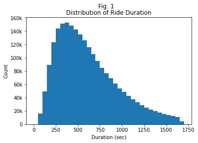

## Who are the most active users of the scheme?

> User Type is a feature describing if a user is a registered member on the scheme or just a casual rider. A large proportion of trips on the bike sharing scheme were taken by subscribers.

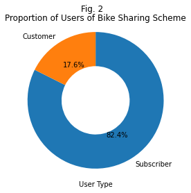

## How does ride duration differ with user type?

Plotting ride duration by user type shows the difference in user behaviour between both groups. While registered members completed more trips lasting predominantly around 250 and 500 secs, casual riders showed a more even distribution with a fatter tail showing prevalence of long duration trips.

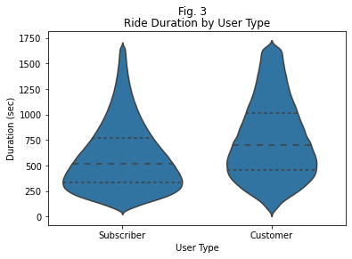

## What's the driving the difference in duration by User Type?

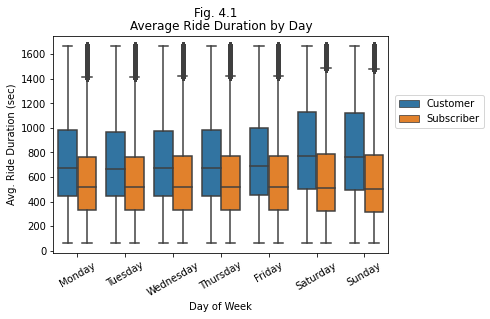

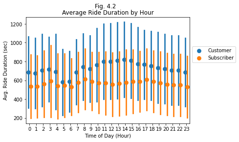

## How Does User Activity Differ by Month?

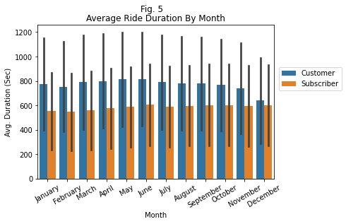